# Project Loan Dataset exploration by Augustine ugbeda

```python
# import all packages and set plots to be embedded inline
import numpy as np
import pandas as pd
#pd.options.mode.chained_assignment = None
import matplotlib.pyplot as plt
import seaborn as sns
import datetime
%matplotlib inline
```

```python
# load in the dataset into a pandas dataframe, print statistics
loan = pd.read_csv('prosperLoanData.csv')
```

```python
# high-level overview of data shape and composition
print(loan.shape)
print(loan.dtypes)
print(loan.head(10))
```

```
(113937, 81)
ListingKey                      object
ListingNumber                    int64
ListingCreationDate             object
CreditGrade                     object
Term                             int64
                                ...
PercentFunded                  float64
Recommendations                  int64
InvestmentFromFriendsCount       int64
InvestmentFromFriendsAmount    float64
Investors                        int64
Length: 81, dtype: object
                ListingKey  ListingNumber            ListingCreationDate  \
0  1021339766868145413AB3B         193129  2007-08-26 19:09:29.263000000
```

[output cut: 71 more lines]

### Data Cleaning

```python
#picking columns of interest
columns=['ListingNumber','ListingCreationDate','LoanOriginalAmount','LoanStatus','ListingCategory (numeric)','BorrowerState','BorrowerAPR','BorrowerRate','StatedMonthlyIncome', 'ProsperRating (Alpha)',
        'Occupation','Term','EmploymentStatus','TotalInquiries','DebtToIncomeRatio','MonthlyLoanPayment','TotalTrades','Investors']
loan_main=loan[columns]
```

```python
#checking info
loan_main.info()
```

```
<class 'pandas.core.frame.DataFrame'>
RangeIndex: 113937 entries, 0 to 113936
Data columns (total 18 columns):
 #   Column                     Non-Null Count   Dtype
---  ------                     --------------   -----
 0   ListingNumber              113937 non-null  int64
 1   ListingCreationDate        113937 non-null  object
 2   LoanOriginalAmount         113937 non-null  int64
 3   LoanStatus                 113937 non-null  object
 4   ListingCategory (numeric)  113937 non-null  int64
 5   BorrowerState              108422 non-null  object
 6   BorrowerAPR                113912 non-null  float64
 7   BorrowerRate               113937 non-null  float64
 8   StatedMonthlyIncome        113937 non-null  float64
 9   ProsperRating (Alpha)      84853 non-null   object
 10  Occupation                 110349 non-null  object
 11  Term                       113937 non-null  int64
 12  EmploymentStatus           111682 non-null  object
 13  TotalInquiries             112778 non-null  float64
 14  DebtToIncomeRatio          105383 non-null  float64
 15  MonthlyLoanPayment         113937 non-null  float64
 16  TotalTrades                106393 non-null  float64
 17  Investors                  113937 non-null  int64
dtypes: float64(7), int64(5), object(6)
memory usage: 15.6+ MB
```

```python
loan_main.head()
```

|  | ListingNumber | ListingCreationDate | LoanOriginalAmount | LoanStatus | ListingCategory (numeric) | BorrowerState | BorrowerAPR | BorrowerRate | StatedMonthlyIncome | ProsperRating (Alpha) | Occupation | Term | EmploymentStatus | TotalInquiries | DebtToIncomeRatio | MonthlyLoanPayment | TotalTrades | Investors |
| --- | --- | --- | --- | --- | --- | --- | --- | --- | --- | --- | --- | --- | --- | --- | --- | --- | --- | --- |
| 0 | 193129 | 2007-08-26 19:09:29.263000000 | 9425 | Completed | 0 | CO | 0.16516 | 0.1580 | 3083.333333 | NaN | Other | 36 | Self-employed | 3.0 | 0.17 | 330.43 | 11.0 | 258 |
| 1 | 1209647 | 2014-02-27 08:28:07.900000000 | 10000 | Current | 2 | CO | 0.12016 | 0.0920 | 6125.000000 | A | Professional | 36 | Employed | 5.0 | 0.18 | 318.93 | 29.0 | 1 |
| 2 | 81716 | 2007-01-05 15:00:47.090000000 | 3001 | Completed | 0 | GA | 0.28269 | 0.2750 | 2083.333333 | NaN | Other | 36 | Not available | 1.0 | 0.06 | 123.32 | NaN | 41 |
| 3 | 658116 | 2012-10-22 11:02:35.010000000 | 10000 | Current | 16 | GA | 0.12528 | 0.0974 | 2875.000000 | A | Skilled Labor | 36 | Employed | 1.0 | 0.15 | 321.45 | 26.0 | 158 |
| 4 | 909464 | 2013-09-14 18:38:39.097000000 | 15000 | Current | 2 | MN | 0.24614 | 0.2085 | 9583.333333 | D | Executive | 36 | Employed | 9.0 | 0.26 | 563.97 | 39.0 | 20 |

```python
#dropping rows where prosperrating is null
loan_main = loan_main[loan_main['ProsperRating (Alpha)'].notnull()]
```

Dealing with missing values

```python
#filling the missing value of DebttoIncomeRatio with the mean
loan_main.DebtToIncomeRatio = loan_main.DebtToIncomeRatio.fillna(loan_main.DebtToIncomeRatio.mean())
##filling missing values for the Occupation as undisclosed
loan_main.Occupation = loan_main.Occupation.fillna('undisclosed')
```

```python
###Dealing with ListingCreationDate column
col=['ListingCreationDate','BorrowerRate']
loan_date=loan_main[col]
# Splitting ListingCreationDate column into year,month,day,time
loan_main['year']=loan_main['ListingCreationDate'].apply(lambda x: x.split("-")[0]).astype(str)
loan_main['month'] = loan_main['ListingCreationDate'].apply(lambda x: x.split("-")[1]).astype(str)

# replacing numerical values of month with names
loan_main.month.replace(['01','02','03','04','05','06','07','08','09','10','11','12'],['Jan','Feb','Mar','Apr','May','Jun','Jul','Aug','Sept','Oct','Nov','Dec'],inplace=True)

loan_main['ListingCreationDate'] = loan_main['ListingCreationDate'].apply(lambda x: x.split("-")[2]).astype(str)
loan_main['day'] = loan_main['ListingCreationDate'].apply(lambda x: x.split(" ")[0]).astype(str)
loan_main['time'] = loan_main['ListingCreationDate'].apply(lambda x: x.split(" ")[1]).astype(str)
# drop the original ListingCreationDate column
loan_main.drop(columns = ['ListingCreationDate'],inplace = True)
```

```python
loan_main.head()
```

|  | ListingNumber | LoanOriginalAmount | LoanStatus | ListingCategory (numeric) | BorrowerState | BorrowerAPR | BorrowerRate | StatedMonthlyIncome | ProsperRating (Alpha) | Occupation | ... | EmploymentStatus | TotalInquiries | DebtToIncomeRatio | MonthlyLoanPayment | TotalTrades | Investors | year | month | day | time |
| --- | --- | --- | --- | --- | --- | --- | --- | --- | --- | --- | --- | --- | --- | --- | --- | --- | --- | --- | --- | --- | --- |
| 1 | 1209647 | 10000 | Current | 2 | CO | 0.12016 | 0.0920 | 6125.000000 | A | Professional | ... | Employed | 5.0 | 0.18 | 318.93 | 29.0 | 1 | 2014 | Feb | 27 | 08:28:07.900000000 |
| 3 | 658116 | 10000 | Current | 16 | GA | 0.12528 | 0.0974 | 2875.000000 | A | Skilled Labor | ... | Employed | 1.0 | 0.15 | 321.45 | 26.0 | 158 | 2012 | Oct | 22 | 11:02:35.010000000 |
| 4 | 909464 | 15000 | Current | 2 | MN | 0.24614 | 0.2085 | 9583.333333 | D | Executive | ... | Employed | 9.0 | 0.26 | 563.97 | 39.0 | 20 | 2013 | Sept | 14 | 18:38:39.097000000 |
| 5 | 1074836 | 15000 | Current | 1 | NM | 0.15425 | 0.1314 | 8333.333333 | B | Professional | ... | Employed | 2.0 | 0.36 | 342.37 | 47.0 | 1 | 2013 | Dec | 14 | 08:26:37.093000000 |
| 6 | 750899 | 3000 | Current | 1 | KS | 0.31032 | 0.2712 | 2083.333333 | E | Sales - Retail | ... | Employed | 0.0 | 0.27 | 122.67 | 16.0 | 1 | 2013 | Apr | 12 | 09:52:56.147000000 |

5 rows × 21 columns

```python
loan_main.to_csv ('loan_main.csv', index = False)
```

```python
#checking for shape and info
loan_main.shape
loan_main.info()
```

```
<class 'pandas.core.frame.DataFrame'>
Int64Index: 84853 entries, 1 to 113936
Data columns (total 21 columns):
 #   Column                     Non-Null Count  Dtype
---  ------                     --------------  -----
 0   ListingNumber              84853 non-null  int64
 1   LoanOriginalAmount         84853 non-null  int64
 2   LoanStatus                 84853 non-null  object
 3   ListingCategory (numeric)  84853 non-null  int64
 4   BorrowerState              84853 non-null  object
 5   BorrowerAPR                84853 non-null  float64
 6   BorrowerRate               84853 non-null  float64
 7   StatedMonthlyIncome        84853 non-null  float64
 8   ProsperRating (Alpha)      84853 non-null  object
 9   Occupation                 84853 non-null  object
 10  Term                       84853 non-null  int64
 11  EmploymentStatus           84853 non-null  object
 12  TotalInquiries             84853 non-null  float64
 13  DebtToIncomeRatio          84853 non-null  float64
 14  MonthlyLoanPayment         84853 non-null  float64
 15  TotalTrades                84853 non-null  float64
 16  Investors                  84853 non-null  int64
 17  year                       84853 non-null  object
 18  month                      84853 non-null  object
 19  day                        84853 non-null  object
 20  time                       84853 non-null  object
dtypes: float64(7), int64(5), object(9)
memory usage: 14.2+ MB
```

### What is the structure of your dataset?

The dataset contains 84853 loans with 21 columns

### What is/are the main feature(s) of interest in your dataset?

I am interested in how employment status and debtToIncome ratio associates with various variables in the dataset.and what features affect Annual Percentage Rate (APR)

### What features in the dataset do you think will help support your investigation into your feature(s) of interest?

I think Employment status and occupation will affect out ProsperRating and loan Amount.i also expect that the APR of the loan will be affected by the total loan amount, the larger the total loan amount, the lower the APR and vice versa. I also think that the borrowers stated monthly income, loan term, Prosper rating, employment status will also have effects on the APR.

### Univariate exploration

i will start by looking at the loan amount

```python
def histogram(x,binsize,bz,title):
    b = np.arange(0, loan_main[x].max()+binsize, bz)
    plt.figure(figsize=[8, 5])
    plt.hist(data = loan_main, x=x , bins = b)
    plt.xlabel(x)
    plt.ylabel("count")

    plt.title(f'Distribution of {title}'.title(),fontsize=14,weight="bold")
```

#### Question

#### What is the distribution of Loan original Amount?

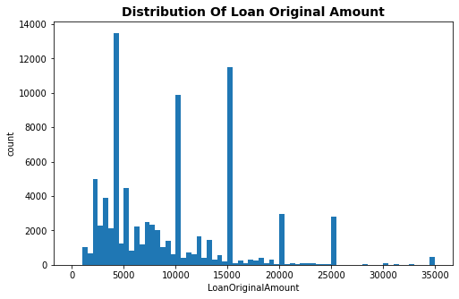

```python
histogram('LoanOriginalAmount',500,500, 'Loan Original Amount')
```

#### Observation

the loan original Amount is multimodl with various peaks,with loan amount of about 4,500 having the most peak

#### Question

#### What is the distribution of Monthly Loan Payment?

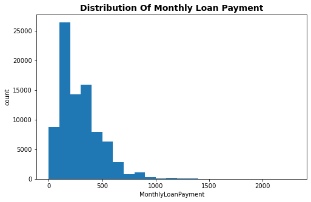

```python
histogram('MonthlyLoanPayment',100,100, 'Monthly Loan Payment')
```

#### Observation

we can see that monthly loan payment majorly falls below 500

#### Question

#### What is the distribution of Borrower Apr?

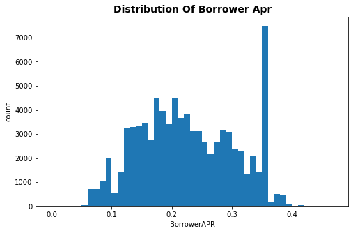

```python
histogram('BorrowerAPR',0.05,0.01, 'Borrower APR')
```

#### Observation

APR distribution is multimodal.Only very few loans have APR greater than 0.4.we have a very shape peak between 0.35 and 0.36 and small peaks centered around 0.1, 0.2, 0.3 respectively.

#### Question

#### What is the distribution of Loan month?

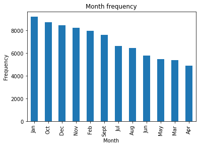

```python
#plotting bar charts that shows hometeam wins,away team wins and draws
loan_main['month'].value_counts().plot.bar()
plt.title('Month frequency')
plt.ylabel('Frequency')
plt.xlabel('Month');
```

#### Observation

January has the most number of loans,as expected since it is the begining of the year.

#### Question

#### What is the distribution of stated monthly income

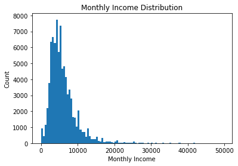

```python
# Distribution of stated monthly income
bins_smi = np.arange(0, 50000, 500)
plt.hist(data = loan_main, x = 'StatedMonthlyIncome', bins=bins_smi)
plt.ylabel('Count')
plt.xlabel('Monthly Income')
plt.title('Monthly Income Distribution');
```

#### Observation

the distribution of monthliy income is rightly skewed with majoity earning below 30000 and majority earning around 5000

```python
# ProsperRating and Employment status conversion into ordered categorical types
order = ['HR','E','D','C','B','A','AA']
ordered = pd.api.types.CategoricalDtype(ordered = True,
                                    categories = order)
loan_main['ProsperRating (Alpha)'] = loan_main['ProsperRating (Alpha)'].astype(ordered)

order_employ = ['Employed','Self-employed','Full-time','Part-time','Retired','Other','Not employed', 'Not available']
ordered_employ = pd.api.types.CategoricalDtype(ordered = True,
                                    categories = order_employ)
loan_main['EmploymentStatus'] = loan_main['EmploymentStatus'].astype(ordered_employ)
```

#### Question

#### What employment status ,state and loan status has the most frequencies?

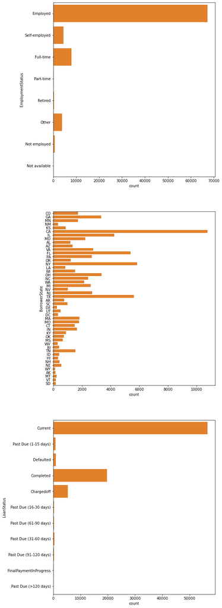

```python
fig, ax = plt.subplots(nrows=3, figsize = [8,30])

default_color = sns.color_palette()[1]
sns.countplot(data = loan_main, y = 'EmploymentStatus', color = default_color, ax = ax[0])
sns.countplot(data = loan_main, y = 'BorrowerState', color = default_color, ax = ax[1])
sns.countplot(data = loan_main, y = 'LoanStatus', color = default_color, ax = ax[2])

plt.show()
```

#### Observation

Majority of the loans are obtained by employed people,while not employed and part time workers obtain less loans.we can also se that more of the loans are obtained by those in the state of crlifornia and most loans are have current status

#### Question

#### What is occupation has the most frequency?

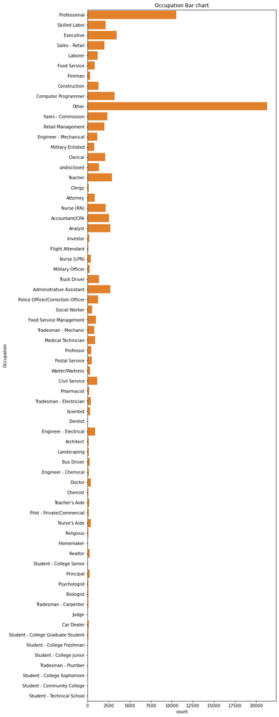

```python
fig, ax = plt.subplots( figsize = [8,30])

sns.countplot(data = loan_main, y = 'Occupation', color = default_color)
plt.title('Occupation Bar chart');
```

#### Observation

Majority of the loans are current loans followed by completed loans.most borrowers are from the state of carlifornia.Most of borrowers are employed and full-time.The least SET of the borrowers are students.

### Were there any unusual points? Did you need to perform any transformations?

There are no unusual points and no need to perform any transformations.

### Of the features investigated, were there any unusual distributions? Did you perform any operations on the data to tidy, adjust, or change the form of the data? If so, why did you do this?

stated monthly income is highly right screwed. There is no need to perform any transformations.

## Bivarate Exploration

i start by looking at correlation between variables

```python
num_vars = ['LoanOriginalAmount', 'BorrowerAPR', 'StatedMonthlyIncome','DebtToIncomeRatio','Investors']
cat_vars = ['Term','ProsperRating', 'EmploymentStatus','Occupation']
```

#### Question

#### What is correlation between the numerical variables?

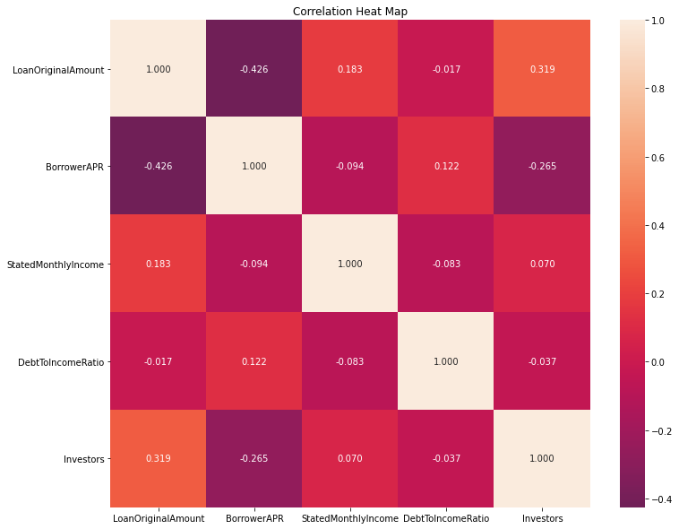

```python
plt.figure(figsize = [12, 10])
sns.heatmap(loan_main[num_vars].corr(), annot = True, fmt = '.3f',
           cmap = 'rocket', center = 0)
plt.title('Correlation Heat Map');
```

#### Observation

The loan original amount is positively correlated with the stated monthly income with a coefficient of 0.18,The correlation coefficient of borrower APR and loan original amount is -0.426

```
loan_main.shape= (84853, 21)
loan_main_samp.shape= (600, 21)
```

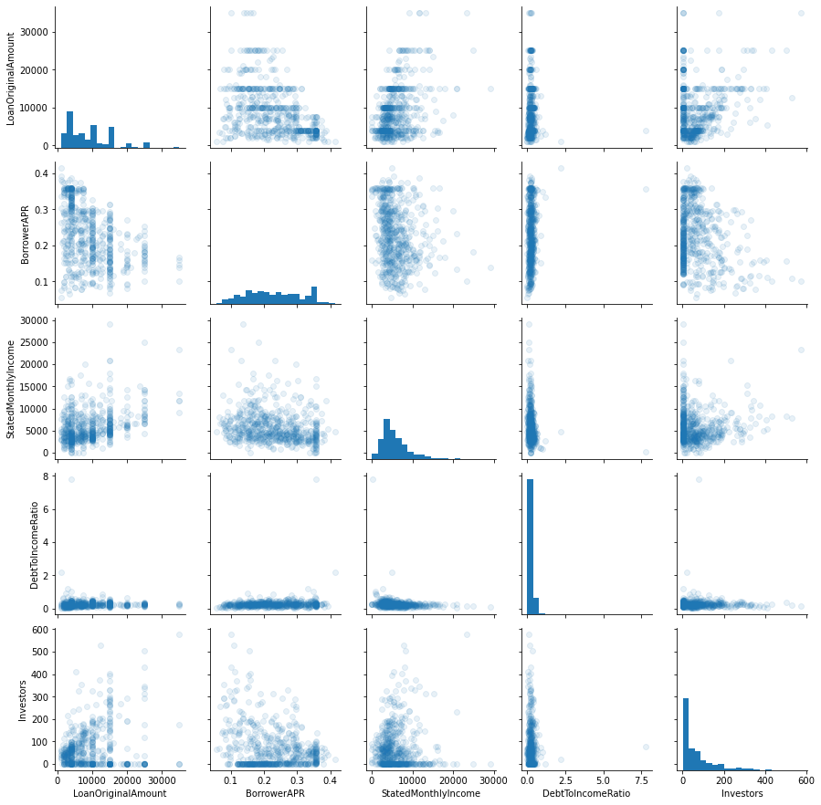

```python
# plot matrix: sample of 600
print("loan_main.shape=",loan_main.shape)
loan_main_samp = loan_main.sample(n=600, replace = False)
print("loan_main_samp.shape=",loan_main_samp.shape)

g = sns.PairGrid(data = loan_main_samp, vars = num_vars)
g = g.map_diag(plt.hist, bins = 20);
g.map_offdiag(plt.scatter,alpha=0.1);
```

#### Observation

the two variables of borrower APR and loan original amount are also negatively correlated when we look at the scatter plot, which agrees with the assumption that the more the loan amount, the lower the APR.

```python
#ListingCreationDate

loan_date.loc[:,'ListingCreationDate'] = loan_date['ListingCreationDate'].apply(pd.to_datetime)
loan_date.loc[:,'Week'] = loan_date['ListingCreationDate'].dt.isocalendar().week
loan_date.loc[:,'Week'] = np.array(loan_date.Week, dtype=float)
```

[output not shown]

```python
print (loan_date.Week)
```

```
1          9.0
3         43.0
4         37.0
5         50.0
6         15.0
          ...
113932    15.0
113933    44.0
113934    50.0
113935    46.0
113936     3.0
Name: Week, Length: 84853, dtype: float64
```

#### Question

#### What is the borrower rate over time?

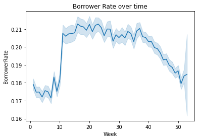

```python
sns.lineplot(x="Week", y="BorrowerRate", data=loan_date).set(title='Borrower Rate over time')
plt.show()
```

the line graph shows the variations of borrower rate over time

```python
#subsetting the loans into groups
loan_good= loan_main[loan_main['LoanStatus'].str.contains('Completed|Current|Final')]
loan_bad= loan_main[~loan_main['LoanStatus'].str.contains('Completed|Current|Final')]
#further subseting
loan_completed=loan_good[loan_good['LoanStatus'].str.contains('Completed')]
loan_problem= loan_bad[loan_bad['LoanStatus'].str.contains('Defaulted|Chargedoff|Cancelled')]
loan_late=loan_bad[~loan_bad['LoanStatus'].str.contains('Defaulted|Chargedoff|Cancelled')]
```

checking the subsets of loans

```python
loan_bad.LoanStatus.unique()
```

```
array(['Past Due (1-15 days)', 'Defaulted', 'Chargedoff',
       'Past Due (16-30 days)', 'Past Due (61-90 days)',
       'Past Due (31-60 days)', 'Past Due (91-120 days)',
       'Past Due (>120 days)'], dtype=object)
```

```python
loan_late.LoanStatus.unique()
```

```
array(['Past Due (1-15 days)', 'Past Due (16-30 days)',
       'Past Due (61-90 days)', 'Past Due (31-60 days)',
       'Past Due (91-120 days)', 'Past Due (>120 days)'], dtype=object)
```

```python
loan_late.LoanStatus.unique()
```

```
array(['Past Due (1-15 days)', 'Past Due (16-30 days)',
       'Past Due (61-90 days)', 'Past Due (31-60 days)',
       'Past Due (91-120 days)', 'Past Due (>120 days)'], dtype=object)
```

#### Question

#### How do problematic loans and loans that are late in payment compare?

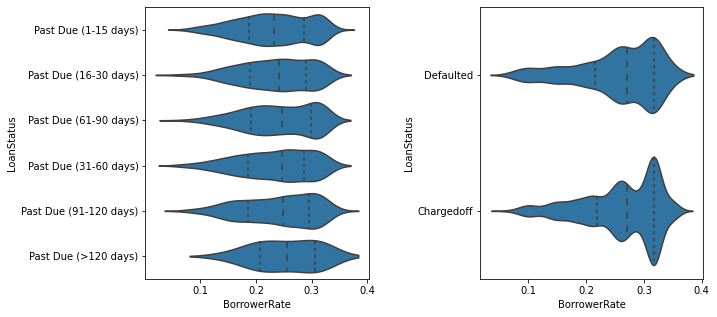

```python
#comparing problematic loans and loans that are late in payment
default_color = sns.color_palette()[0]
plt.figure(figsize=[10,5])
plt.subplots_adjust(wspace=0.5)
plt.subplot(1,2,1)
sns.violinplot(data=loan_late,y="LoanStatus",x="BorrowerRate",inner="quartile",color=default_color)
plt.subplot(1,2,2)
sns.violinplot(data=loan_problem,y="LoanStatus",x="BorrowerRate",inner="quartile",color=sns.color_palette()[0]);
```

#### Observation

the means for the borrow rate of late loans are around 0.25 while that of problematic loans also around to 0.25

#### Question

#### How do problematic loans and loans that are late in payment and completed loans compare?

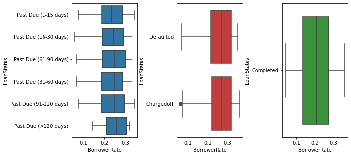

```python
#comparing problematic loans and loans that are late in payment and completed loans
default_color = sns.color_palette()[0]
plt.figure(figsize=[10,5])
plt.subplots_adjust(wspace=0.6)
plt.subplot(1,3,1)
sns.boxplot(data=loan_late,y="LoanStatus",x="BorrowerRate",color=default_color)
plt.subplot(1,3,2)
sns.boxplot(data=loan_problem,y="LoanStatus",x="BorrowerRate",color=sns.color_palette()[3])
plt.subplot(1,3,3)
sns.boxplot(data=loan_completed,y="LoanStatus",x="BorrowerRate",color=sns.color_palette()[2]);
```

#### Question

#### what is the disribution of Prosper Rating according to term?

#### what is the disribution of Employment status according to term?

#### what is the disribution of Prosper Rating and Employment Status?

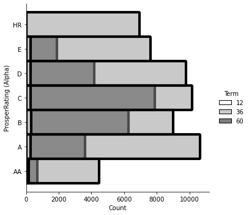

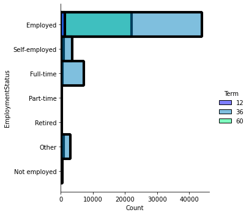

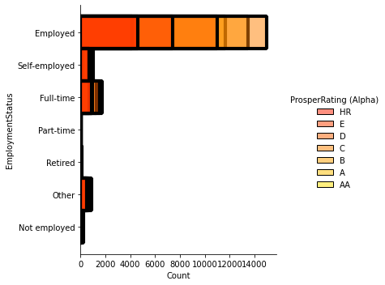

```python
###distribution plot




sns.displot(data=loan_main,y="ProsperRating (Alpha)", hue = 'Term',palette = 'Greys')

sns.displot(data = loan_main, y = 'EmploymentStatus', hue = 'Term', palette = 'winter')

sns.displot(data = loan_main, y = 'EmploymentStatus', hue = 'ProsperRating (Alpha)', palette = 'autumn');
```

#### Observation

those with prosper rating (alpha) of HR have only loans with term 36 while those with rating C have more long term loans of 60 compared to other ratings Employed people have different loan term distributions as comared to those that are self employed

## multivariate

#### Question

#### what is the relationship between APR and loan amount?

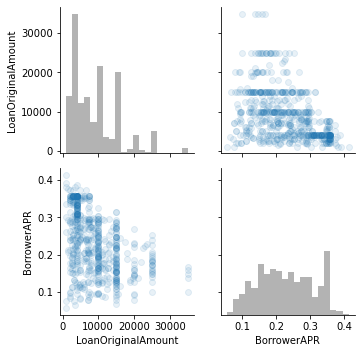

```python
##relationship of APR and loan amount
variables=['LoanOriginalAmount', 'BorrowerAPR']
rep = sns.PairGrid(data = loan_main_samp, vars = variables)
rep = rep.map_diag(plt.hist, bins = 20,color=".7");
rep.map_offdiag(plt.scatter,alpha=0.1);
```

#### Question

#### what is the disribution of Prosper Rating,Borrower APR as regards to term ?

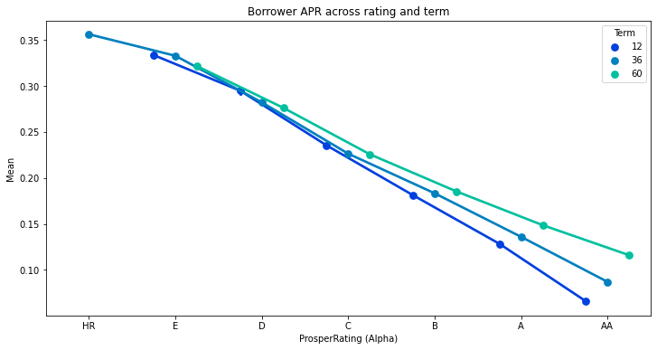

```python
fig = plt.figure(figsize = [12,6])
s= sns.pointplot(data = loan_main, x = 'ProsperRating (Alpha)', y = 'BorrowerAPR', hue = 'Term',
           palette = 'winter',dodge = 0.5).set(title='Borrower APR across rating and term')

plt.ylabel('Mean');
```

#### observation

from the chart,we can see that there is decrease in the the borrower APR with the increase of borrow term for people with HR-C raings. But for people with B-AA ratings, they is the APR increase with the increase of borrow term.

#### Question

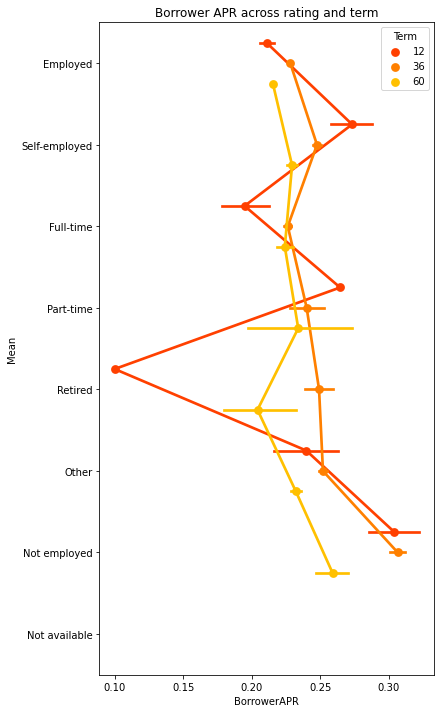

```python
fig = plt.figure(figsize = [6,12])
s = sns.pointplot(data = loan_main, y = 'EmploymentStatus', x = 'BorrowerAPR', hue = 'Term',
           palette = 'autumn',dodge=0.5)
plt.title('Borrower APR across rating and term')
plt.ylabel('Mean')
s.set_yticklabels([],minor = True);
```

January has the highest number of loans listed as expected from starting of new year , whereas april sees the least number of loans listed.

The distribution of APR looks multimodal. A small peak centered at 0.1, a large peak centered at 0.2. There is also a small peak centered 0.3. Additionally, there is a very shape peak between 0.35 and 0.36. Only very few loans have APR greater than 0.43.

The borrower APR decreases with the increasingly better rating. Borrowers with the best Prosper ratings have the lowest APR. It means that the Prosper rating has a strong effect on borrower APR.

Interestingly, the borrower APR decrease with the increase of borrow term for people with HR-C raings. But for people with B-AA ratings, the APR increase with the increase of borrow term.